# Test Plots

Y & J Code Craze

This document contains all of our test plots and the tidying that went along with them. We wanted to use this document to show our process and to document the rest of the work we did.

```r
library(tidyverse)
library(broom)
library(tidyverse)
library(broom)
library(leaflet)
library(colorspace)
library(sf)
library(visdat)
library(naniar)
library(UpSetR)
library(RColorBrewer)

Internship_Data_Untidy <- read.csv("/cloud/project/data/Internship_Data_Untidy.csv")
Tidy_Mapped_Clean <- read.csv("/cloud/project/data/Tidy_Mapped_Clean.csv")
Internship_Leaflet_Official_Complete <- read_csv("/cloud/project/data/Internship_Leaflet_Official - Complete.csv")
```

## Data Clean Up + Extra Steps Associated with Different Test Plots

A lot of this is repeat info - sorry.

```r
Internship_Data_Untidy %>%
  mutate(Term = case_when(
    Term %in% c("NA", "Not Stated", "-", "", "NA ", "All Year", "n/a", "Year", "Year-round", "N/A", "Previous Work Experience", "Nine Months", "Prior Fulfillment"))) ~ "NA" %>%
  mutate(Term = str_squish(Term))
```

```
## Internship_Data_Untidy %>% mutate(Term = case_when(Term %in%
##     c("NA", "Not Stated", "-", "", "NA ", "All Year", "n/a",
##         "Year", "Year-round", "N/A", "Previous Work Experience",
##         "Nine Months", "Prior Fulfillment"))) ~ "NA" %>% mutate(Term = str_squish(Term))
```

#### Step 1 b.) Ensure all terms corespond to one COA term.

```r
Tidy_Term <- Internship_Data_Untidy %>%
mutate(Term = case_when(
  Term %in% c("Fall", "Winter, Spring, Fall", "Winter, Fall", "Summer-Fall", "Spring, Fall", "Summer/Fall", "Summer, Fall", "Spring, Summer, Fall", "Summer,Fall", "Winter+Fall") ~ "Fall",
  Term %in% c("Winter", "Winter, Fall, Winter", "Fall/Winter", "December-December", "Summer, Fall, Winter", "Fall-Winter", "Fall, Winter", "Summer-Winter") ~ "Winter",
  Term %in% c("Spring", "Fall, Winter, Spring", "spring", "Winter, Spring", "Winter-Spring", "Novermber-Spring", "Summer, Spring, Spring") ~ "Spring",
  Term %in% c("Summer", "Fall, Summer", "August", "Winter-Summer", "Winter, Spring, Summer", "Winter, Summer", "Spring, Summer", "Fall+Summer", "Spring/Summer", "Fall, Winter, Spring, Summer", "Summe", "Summer 2011") ~ "Summer"
))
```

#### Step 1 c.) Yay it’s tidy!

```r
Tidy_Term %>%
  group_by(Term) %>%
  summarise(count = n())
```

```
## # A tibble: 5 × 2
##   Term   count
##   <chr>  <int>
## 1 Fall     228
## 2 Spring   197
## 3 Summer   815
## 4 Winter   256
## 5 <NA>     153
```

### Step 2: Tidy the Year Column (All work applied to data frame “Tidy_Term”)

#### Step 2 a.) Check for all unique variables within the Year coloumn

```r
unique(Tidy_Term$Year)
```

```
##  [1] "2015"             "2011"             "2017"             "1997"
##  [5] "2009"             "2007"             "1976-79"          "2014"
##  [9] "2019"             "1999"             "2016"             "2010"
## [13] "1991"             "2004"             "2002"             "1994"
## [17] "2022"             "1996-1999"        "1995"             "2001"
## [21] "1990"             "1985"             "2005"             "2013"
## [25] "1996"             "1987"             "1979"             "1998"
## [29] "1982"             "2009-2011"        "2020"             "2021"
## [33] "1992"             "1988"             "2006"             "2000"
## [37] "1993"             "1986"             "2003"             "2012"
## [41] "2018"             "1977"             "2008"             "1976"
## [45] "1978"             "1973"             "1974, 1975"       "1997, 1998, 1999"
## [49] "1983"             "1980"             "1984"             "1996-2008"
## [53] "1989"             "1981"             "1974"             "1995, 1996"
## [57] "1990s?"           "2003, 2004, 2005" NA                 "2013-2014"
## [61] "1978, 1979, 1980" "2015, 2016, 2017" "2017-18"          "Varied"
## [65] "2002-03"          "1975"             "1981, 1982"       "1981-1983"
## [69] "2002 - 2009"      "2014-15"          "1979 and 1980"    "2023"
## [73] "1973, 1974, 1975" "≤2000"            "1977, 1975, 1972" "2001, 2002"
## [77] "1985, 1986"       "1987, 1988"       "1998/1999"        "1994-1997"
## [81] "2006, 2007"       ""                 "1977, 1978"       "1987-1993"
## [85] "2009-2010"        "1970"             "1984, 1985"       "1997, 1998"
## [89] "1989-1996"        "2001-2002"        "2015, 2016"       "1994-95"
## [93] "1994, 1995, 1996" "1980-1982"
```

#### Step 2 b.) Ensure all variables follow same format

```r
Tidy_Time <- Tidy_Term %>%
mutate(Year = case_when(
  Year %in% c("1970") ~ "1970",
  Year %in% c("1973", "1973, 1974, 1975") ~ "1973",
  Year %in% c("1974") ~ "1974",
  Year %in% c("1975", "1974, 1975") ~ "1975",
  Year %in% c("1976") ~"1976",
  Year %in% c("1977", "1977, 1975, 1972") ~ "1977",
  Year %in% c("1978", "1977,1978") ~ "1978",
  Year %in% c("1979","1976-79") ~ "1979",
  Year %in% c("1980", "1978, 1979, 1980", "1979 and 1980") ~ "1980",
  Year %in% c("1981") ~ "1981",
  Year %in% c("1982", "1981, 1982") ~ "1982",
  Year %in% c("1983","1981-1983") ~ "1983",
  Year %in% c("1984") ~ "1984",
  Year %in% c("1985", "1984, 1985") ~ "1985",
  Year %in% c("1986", "1985, 1986") ~ "1986",
  Year %in% c("1987") ~"1987",
  Year %in% c("1988", "1987, 1988") ~ "1988",
  Year %in% c("1989") ~ "1989",
  Year %in% c("1990") ~ "1990",
  Year %in% c("1991") ~ "1991",
  Year %in% c("1992") ~ "1992",
  Year %in% c("1993", "1987-1993") ~ "1993",
  Year %in% c("1994") ~ "1994",
  Year %in% c("1995") ~ "1995",
  Year %in% c("1996", "1994, 1995, 1996", "1995, 1996") ~ "1996",
  Year %in% c("1997") ~ "1997",
  Year %in% c("1998", " 1997, 1998") ~ "1998",
  Year %in% c("1999", "1997, 1998, 1999", "1998/1999") ~ "1999",
  Year %in% c("2000") ~ "2000",
  Year %in% c("2001") ~ "2001",
  Year %in% c("2002", "2001, 2002") ~ "2002",
  Year %in% c("2003") ~ "2003",
  Year %in% c("2004") ~"2004",
  Year %in% c("2005", "2003, 2004, 2005") ~ "2005",
  Year %in% c("2006") ~ "2006",
  Year %in% c("2007", "2006, 2007") ~ "2007",
  Year %in% c("2008", "1996-2008") ~ "2008",
  Year %in% c("2009","2002 - 2009") ~ "2009",
  Year %in% c("2010", "2009-2010") ~ "2010",
  Year %in% c("2011","  2009-2011") ~ "2011",
  Year %in% c("2012") ~ "2012",
  Year %in% c("2013") ~ "2013",
  Year %in% c("2014", " 2013-2014") ~ "2014",
  Year %in% c("2015", "2014-15") ~ "2015",
  Year %in% c("2016", " 2015, 2016") ~ "2016",
  Year %in% c("2017", " 2015, 2016, 2017") ~ "2017",
  Year %in% c("2018") ~ "2018",
  Year %in% c("2019") ~ "2019",
  Year %in% c("2020") ~ "2020",
  Year %in% c("2021") ~ "2021",
  Year %in% c("2022") ~ "2022",
  Year %in% c("2023") ~ "2023"
))
```

#### Step 2 c.) Double check unique terms

```r
Tidy_Time %>%
  group_by(Year) %>%
  summarise(count = n())
```

```
## # A tibble: 53 × 2
##    Year  count
##    <chr> <int>
##  1 1970      1
##  2 1973      5
##  3 1974      4
##  4 1975      6
##  5 1976      8
##  6 1977     11
##  7 1978     24
##  8 1979     23
##  9 1980     27
## 10 1981     28
## # ℹ 43 more rows
```

Yay! it’s all tidy!

### Step 3 Create a Decade Variable

Decade variable for different data sets used to create different plots.

```r
Tidy_Mapped_Clean <- Tidy_Mapped_Clean %>%
  mutate(Decade = (floor(Year/10)*10))
```

```r
Internship_Leaflet_Official_Complete <- Internship_Leaflet_Official_Complete %>%
  mutate(Decade = (floor(Year/10)*10))
```

### Step 4 Create Local, Domestic, and International Catagories

```r
us_states <- c("Alabama", "Alaska", "Arizona", "Arkansas", "California", "Colorado",
               "Connecticut", "Delaware", "Florida", "Georgia", "Hawaii", "Idaho",
               "Illinois", "Indiana", "Iowa", "Kansas", "Kentucky", "Louisiana",
               "Maine", "Maryland", "Massachusetts", "Michigan", "Minnesota",
               "Mississippi", "Missouri", "Montana", "Nebraska", "Nevada",
               "New Hampshire", "New Jersey", "New Mexico", "New York",
               "North Carolina", "North Dakota", "Ohio", "Oklahoma", "Oregon",
               "Pennsylvania", "Rhode Island", "South Carolina", "South Dakota",
               "Tennessee", "Texas", "Utah", "Vermont", "Virginia", "Washington",
               "West Virginia", "Wisconsin", "Wyoming")
Internship_Leaflet_Official_Complete <- Internship_Leaflet_Official_Complete %>%
mutate(region = str_extract(Location, "(?<=, ).+$"),
       Location_Type = case_when(
         Location %in% c("Bar Harbor, Maine", "Northeast Harbor, Maine", "Southwest Harbor, Maine", "Otter Creek, Maine", "Seal Cove, Maine", "Mount Desert, Maine", "Mount Desert Island, Maine", "Hulls Cove, Maine", "Town Hill, Maine", "Somesville, Maine", "Salsbury Cove, Maine") ~ "Local",
      region %in% us_states ~ "Domestic",
      TRUE ~ "International"))
```

### Test Plots: Year-Term Bar Polar Charts

Polar chart of terms by year:

```r
Tidy_Time_Summary <- Tidy_Time %>%
  drop_na(Term) %>%
  drop_na(Year) %>%
  group_by(Year, Term) %>%
  summarise(count = n()) %>%
  ungroup()
```

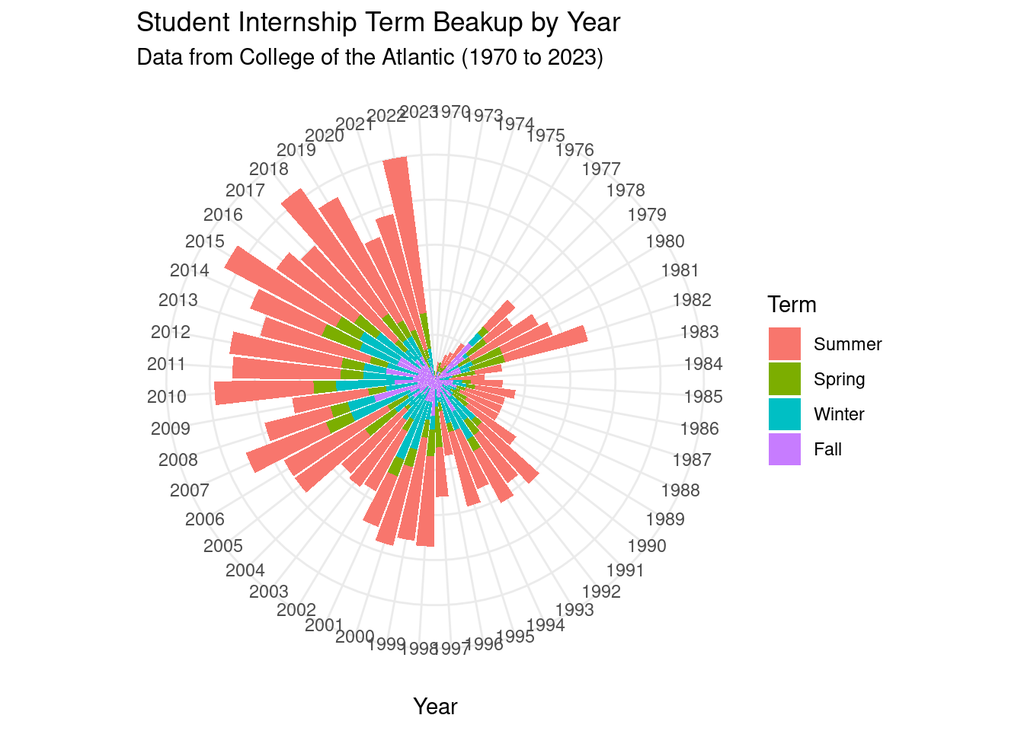

```r
Tidy_Time_Summary %>%
  ggplot(aes(x = Year, y = count, fill = fct_relevel(Term, c("Summer", "Spring", "Winter", "Fall")))) +
  geom_bar(stat = "identity", position = "stack") +
  coord_polar(start = 0) +
  labs(
    title = "Student Internship Term Beakup by Year",
    subtitle = "Data from College of the Atlantic (1970 to 2023)",
    x = "Year",
    fill = "Term") +
  theme_minimal() +
  theme(axis.title.y = element_blank(),
        axis.line = element_blank(),
        axis.ticks = element_blank(),
        axis.text.y = element_blank())
```

Polar chart of terms from all years:

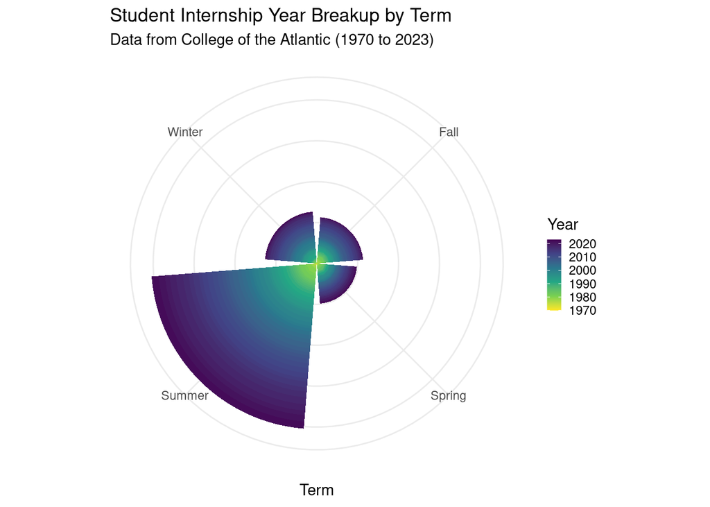

```r
Tidy_Time_Summary %>%
  ggplot(aes(x = Term, y = count, fill = as.numeric(Year))) +
  geom_bar(stat = "identity", position = "stack") +
  coord_polar(start = 0) +
  labs(
    title = "Student Internship Year Breakup by Term",
    subtitle = "Data from College of the Atlantic (1970 to 2023)",
    x = "Term",
    fill = "Year") +
  theme_minimal() +
  theme(axis.title.y = element_blank(),
        axis.text.y = element_blank(),
        legend.key.size = unit(0.7, "lines")) +
  scale_fill_viridis_c(direction = -1)
```

Same idea, but split up by decade instead of year:

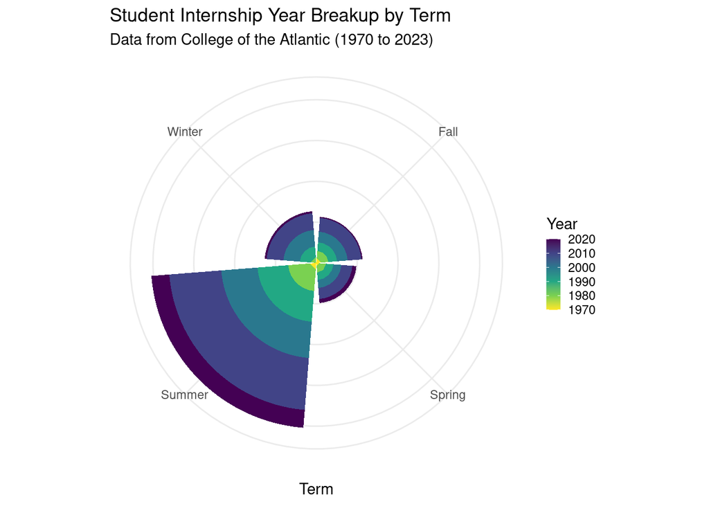

```r
Internship_Leaflet_Official_Complete %>%
  drop_na(Term) %>%
  drop_na(Decade) %>%
  group_by(Decade, Term) %>%
  summarise(count = n()) %>%
  ungroup() %>%
  ggplot(aes(x = Term, y = count, fill = as.numeric(Decade))) +
  geom_bar(stat = "identity", position = "stack") +
  coord_polar(start = 0) +
  labs(
    title = "Student Internship Year Breakup by Term",
    subtitle = "Data from College of the Atlantic (1970 to 2023)",
    x = "Term",
    fill = "Year") +
  theme_minimal() +
  theme(axis.title.y = element_blank(),
        axis.text.y = element_blank(),
        legend.key.size = unit(0.7, "lines")) +
  scale_fill_viridis_c(direction = -1)
```

More variations, but make it a bar plot:

Harder to compare decades, but it does show the overall trends in term data. It’s also not as cool as the polar chart.

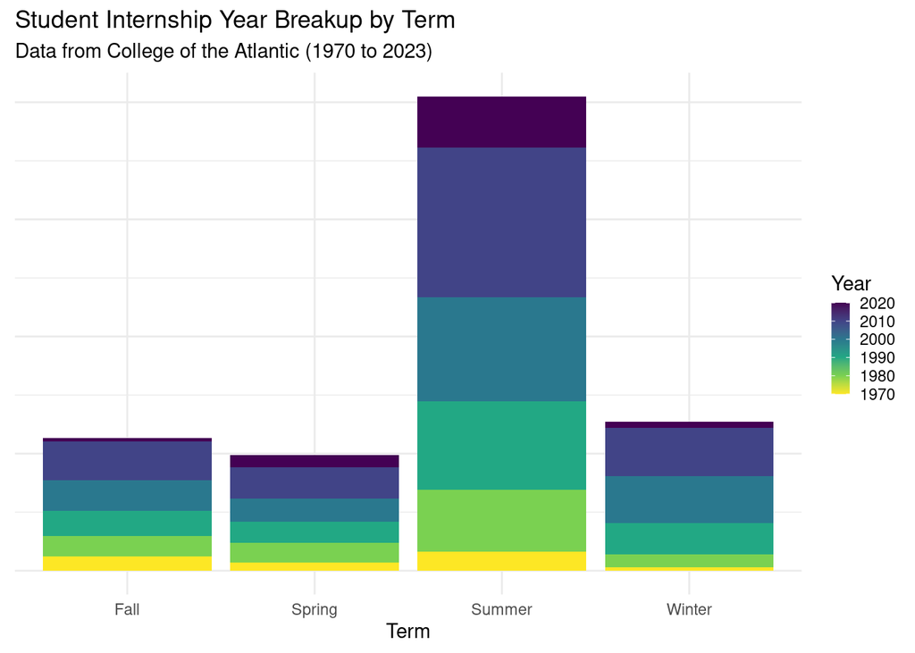

```r
Internship_Leaflet_Official_Complete %>%
  drop_na(Term) %>%
  drop_na(Decade) %>%
  group_by(Decade, Term) %>%
  summarise(count = n()) %>%
  ungroup() %>%
  ggplot(aes(x = Term, y = count, fill = as.numeric(Decade))) +
  geom_bar(stat = "identity", position = "stack") +
  labs(
    title = "Student Internship Year Breakup by Term",
    subtitle = "Data from College of the Atlantic (1970 to 2023)",
    x = "Term",
    fill = "Year") +
  theme_minimal() +
  theme(axis.title.y = element_blank(),
        axis.text.y = element_blank(),
        legend.key.size = unit(0.7, "lines")) +
  scale_fill_viridis_c(direction = -1)
```

It was harder to compare across decades and this doesn’t show how many more internships happen in the summer

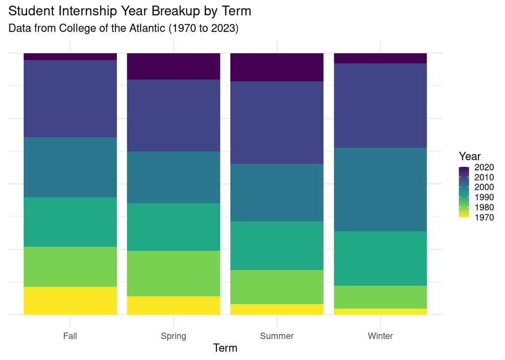

```r
Internship_Leaflet_Official_Complete %>%
  drop_na(Term) %>%
  drop_na(Decade) %>%
  group_by(Decade, Term) %>%
  summarise(count = n()) %>%
  ungroup() %>%
ggplot(aes(x = Term, y = count, fill = as.numeric(Decade))) +
  geom_bar(stat = "identity", position = "fill") +
  labs(
    title = "Student Internship Year Breakup by Term",
    subtitle = "Data from College of the Atlantic (1970 to 2023)",
    x = "Term",
    fill = "Year") +
  theme_minimal() +
  theme(axis.title.y = element_blank(),
        axis.text.y = element_blank(),
        legend.key.size = unit(0.7, "lines")) +
  scale_fill_viridis_c(direction = -1)
```

### Test Plots: Decade-Location Type Plots

We thought this wasn’t the best way to compare changes over each decade.

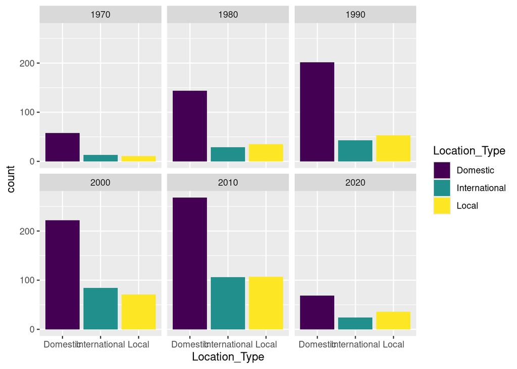

```r
Internship_Leaflet_Official_Complete %>%
  filter(Decade != "NA") %>%
  ggplot(aes(x = Location_Type,
             fill = Location_Type)) +
 geom_bar() +
   facet_wrap(~Decade) +
  scale_fill_viridis_d()
```

This one is interesting to look at, but there is too much going on.

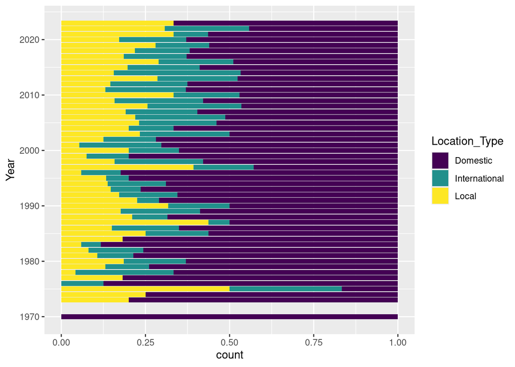

```r
Internship_Leaflet_Official_Complete %>%
  ggplot(aes(y = Year,
         fill = Location_Type)) +
  geom_bar(position = "fill") +
  scale_fill_viridis_d()
```

This one almost made it onto our poster, but we figured that it would be more interesting to have more variation in our visualizations (we have so many bar charts).

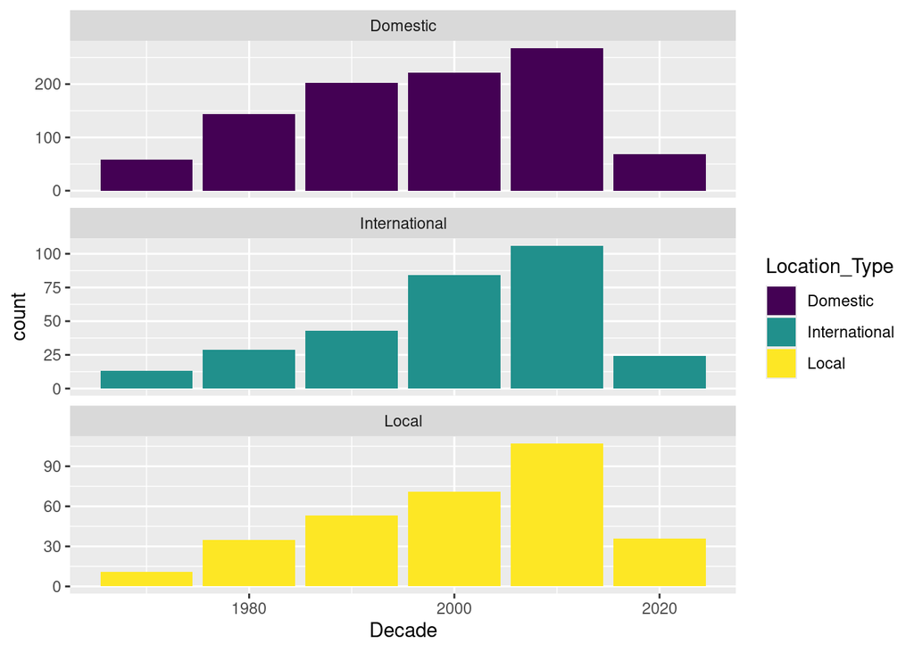

```r
Internship_Leaflet_Official_Complete %>%
ggplot(aes(x = Decade,
             fill = Location_Type)) +
 geom_bar(position = "stack") +
  facet_wrap(~Location_Type, nrow = 3, scales = "free_y") +
  scale_fill_viridis_d()
```

### Test Plots: Old Leaflet Map

All internships without all of the lat/lons entered (pre-Yeshaya-magic):

```r
leaflet(Tidy_Mapped_Clean) %>%
  addTiles() %>%
  setView(lng = mean(Tidy_Mapped_Clean$Longitude, na.rm = TRUE),
          lat = mean(Tidy_Mapped_Clean$Latitude, na.rm = TRUE),
          zoom = 2) %>%
  addMarkers(~Longitude, ~Latitude,
             clusterOptions = markerClusterOptions(),
             popup = ~paste(Internship.Site, "<br>", Location))
```

[interactive chart not shown]

Same thing, but with the decade layers:

```r
#building leaflet
#Things to change: decade, clustering (for later), sliding scale
pal <- colorFactor(palette = c("red", "orange", "yellow", "green", "blue", "purple"), domain = Tidy_Mapped_Clean$Decade)

leaflet(Tidy_Mapped_Clean) %>%
  addTiles() %>%
  setView(lng = mean(Tidy_Mapped_Clean$Longitude, na.rm = TRUE),
          lat = mean(Tidy_Mapped_Clean$Latitude, na.rm = TRUE),
          zoom = 2) %>%
  addCircleMarkers(data = Tidy_Mapped_Clean %>% filter(Decade == "1970"),
                   ~Longitude,
                   ~Latitude,
                   color = ~pal(Decade),
                   group = "1970s",
                   popup = ~paste(Internship.Site, "<br>", Location),
                   clusterOptions = markerClusterOptions()) %>%
  addCircleMarkers(data = Tidy_Mapped_Clean %>% filter(Decade == "1980"),
                   ~Longitude,
                   ~Latitude,
                   color = ~pal(Decade),
                   group = "1980s",
                   popup = ~paste(Internship.Site, "<br>", Location),
                   clusterOptions = markerClusterOptions()) %>%
  addCircleMarkers(data = Tidy_Mapped_Clean %>% filter(Decade == "1990"),
                   ~Longitude,
                   ~Latitude,
                   color = ~pal(Decade),
                   group = "1990s",
                   popup = ~paste(Internship.Site, "<br>", Location),
                   clusterOptions = markerClusterOptions()) %>%
  addCircleMarkers(data = Tidy_Mapped_Clean %>% filter(Decade == "2000"),
                   ~Longitude,
                   ~Latitude,
                   color = ~pal(Decade),
                   group = "2000s",
                   popup = ~paste(Internship.Site, "<br>", Location),
                   clusterOptions = markerClusterOptions()) %>%
  addCircleMarkers(data = Tidy_Mapped_Clean %>% filter(Decade == "2010"),
                   ~Longitude,
                   ~Latitude,
                   color = ~pal(Decade),
                   group = "2010s",
                   popup = ~paste(Internship.Site, "<br>", Location),
                   clusterOptions = markerClusterOptions()) %>%
  addCircleMarkers(data = Tidy_Mapped_Clean %>% filter(Decade == "2020"),
                   ~Longitude,
                   ~Latitude,
                   color = ~pal(Decade),
                   group = "2020s",
                   popup = ~paste(Internship.Site, "<br>", Location),
                   clusterOptions = markerClusterOptions()) %>%
  addLayersControl(overlayGroups = c("1970s", "1980s", "1990s", "2000s", "2010s", "2020s"),
                   options = layersControlOptions())
```

[interactive chart not shown]